# Assignment No. 1

1. Explore the overall structure of the dataset using “str” and “summary” functions.

```r
realtor <- read.csv("C:\\Users\\Precision T3620\\Downloads\\realtor-1.csv")

str(realtor)
```

```
'data.frame':   923159 obs. of  12 variables:
 $ status      : chr  "for_sale" "for_sale" "for_sale" "for_sale" ...
 $ price       : num  105000 80000 67000 145000 65000 179000 50000 71600 100000 300000 ...
 $ bed         : num  3 4 2 4 6 4 3 3 2 5 ...
 $ bath        : num  2 2 1 2 2 3 1 2 1 3 ...
 $ acre_lot    : num  0.12 0.08 0.15 0.1 0.05 0.46 0.2 0.08 0.09 7.46 ...
 $ full_address: chr  "Sector Yahuecas Titulo # V84, Adjuntas, PR, 00601" "Km 78 9 Carr # 135, Adjuntas, PR, 00601" "556G 556-G 16 St, Juana Diaz, PR, 00795" "R5 Comunidad El Paraso Calle De Oro R-5 Ponce, Ponce, PR, 00731" ...
 $ street      : chr  "Sector Yahuecas Titulo # V84" "Km 78 9 Carr # 135" "556G 556-G 16 St" "R5 Comunidad El Paraso Calle De Oro R-5 Ponce" ...
 $ city        : chr  "Adjuntas" "Adjuntas" "Juana Diaz" "Ponce" ...
 $ state       : chr  "Puerto Rico" "Puerto Rico" "Puerto Rico" "Puerto Rico" ...
 $ zip_code    : num  601 601 795 731 680 612 639 731 730 670 ...
 $ house_size  : num  920 1527 748 1800 NA ...
 $ sold_date   : chr  "" "" "" "" ...
```

```r
summary(realtor)
```

```
    status              price                bed              bath           acre_lot
 Length:923159      Min.   :        0   Min.   :  1.00   Min.   :  1.00   Min.   :     0.00
 Class :character   1st Qu.:   269000   1st Qu.:  2.00   1st Qu.:  1.00   1st Qu.:     0.11
 Mode  :character   Median :   475000   Median :  3.00   Median :  2.00   Median :     0.29
                    Mean   :   884123   Mean   :  3.33   Mean   :  2.49   Mean   :    17.08
                    3rd Qu.:   839900   3rd Qu.:  4.00   3rd Qu.:  3.00   3rd Qu.:     1.15
                    Max.   :875000000   Max.   :123.00   Max.   :198.00   Max.   :100000.00
                    NA's   :71          NA's   :131703   NA's   :115192   NA's   :273623
 full_address          street              city              state              zip_code       house_size
 Length:923159      Length:923159      Length:923159      Length:923159      Min.   :  601   Min.   :    100
 Class :character   Class :character   Class :character   Class :character   1st Qu.: 2919   1st Qu.:   1130
 Mode  :character   Mode  :character   Mode  :character   Mode  :character   Median : 7004   Median :   1651
                                                                             Mean   : 6590   Mean   :   2142
                                                                             3rd Qu.:10001   3rd Qu.:   2499
                                                                             Max.   :99999   Max.   :1450112
                                                                             NA's   :205     NA's   :297843
  sold_date
 Length:923159
 Class :character
 Mode  :character
```

2. Specify the type of each variable

```r
cat("status; Catagorical, nominal\n
    price; numeric, continuous\n
    bed; numeric, discrete\n
    bath; numeric, discrete\n
    acre_lot; numeric, continuous\n
    full_address; Catagorical, nominal\n
    street; Catagorical, nominal\n
    city; Catagorical, nominal\n
    state; Catagorical, nominal\n
    zip_code; numeric, discrete\n
    house_size; numeric, continuous\n
    sold_date; Catagorical, nominal\n")
```

```
status; Catagorical, nominal

    price; numeric, continuous

    bed; numeric, discrete

    bath; numeric, discrete

    acre_lot; numeric, continuous

    full_address; Catagorical, nominal

    street; Catagorical, nominal

    city; Catagorical, nominal

    state; Catagorical, nominal

    zip_code; numeric, discrete

    house_size; numeric, continuous

    sold_date; Catagorical, nominal
```

3. Are there any duplicate observations in the data? If so, remove them. You can use “duplicated” or “unique” functions to answer this question.

```r
duplicates <- duplicated(realtor)

num_duplicates <- sum(duplicates)
cat('yes there are many duplicate values, i.e\n')
```

```
yes there are many duplicate values, i.e
```

```r
print(num_duplicates)
```

```
[1] 809370
```

```r
realtor_unique <- realtor[!duplicates, ]
print(realtor_unique)
```

|  | status | price | bed | bath | acre_lot | full_address | street | city | state | zip_code | house_size | sold_date |
| --- | --- | --- | --- | --- | --- | --- | --- | --- | --- | --- | --- | --- |
| 1 | for_sale | 105000 | 3 | 2 | 0.12 | Sector Yahuecas Titulo # V84, Adjuntas, PR, 00601 | Sector Yahuecas Titulo # V84 | Adjuntas | Puerto Rico | 601 | 920 |  |
| 2 | for_sale | 80000 | 4 | 2 | 0.08 | Km 78 9 Carr # 135, Adjuntas, PR, 00601 | Km 78 9 Carr # 135 | Adjuntas | Puerto Rico | 601 | 1527 |  |
| 3 | for_sale | 67000 | 2 | 1 | 0.15 | 556G 556-G 16 St, Juana Diaz, PR, 00795 | 556G 556-G 16 St | Juana Diaz | Puerto Rico | 795 | 748 |  |
| 4 | for_sale | 145000 | 4 | 2 | 0.10 | R5 Comunidad El Paraso Calle De Oro R-5 Ponce, Ponce, PR, 00731 | R5 Comunidad El Paraso Calle De Oro R-5 Ponce | Ponce | Puerto Rico | 731 | 1800 |  |
| 5 | for_sale | 65000 | 6 | 2 | 0.05 | 14 Navarro, Mayaguez, PR, 00680 | 14 Navarro | Mayaguez | Puerto Rico | 680 | NA |  |
| 6 | for_sale | 179000 | 4 | 3 | 0.46 | Bo Calabazas San Sebastian, San Sebastian, PR, 00612 | Bo Calabazas San Sebastian | San Sebastian | Puerto Rico | 612 | 2520 |  |
| 7 | for_sale | 50000 | 3 | 1 | 0.20 | 49.1 140, Ciales, PR, 00639 | 49.1 140 | Ciales | Puerto Rico | 639 | 2040 |  |
| 8 | for_sale | 71600 | 3 | 2 | 0.08 | 3467 St, Ponce, PR, 00731 | 3467 St | Ponce | Puerto Rico | 731 | 1050 |  |
| 9 | for_sale | 100000 | 2 | 1 | 0.09 | 230 Rio De Vida, Ponce, PR, 00730 | 230 Rio De Vida | Ponce | Puerto Rico | 730 | 1092 |  |
| 10 | for_sale | 300000 | 5 | 3 | 7.46 | Pr 120 Bo Maravilla Sur K M # 335, Las Marias, PR, 00670 | Pr 120 Bo Maravilla Sur K M # 335 | Las Marias | Puerto Rico | 670 | 5403 |  |

[output cut: 990 more lines]

```r
NA
```

4. Does any of the variables have missing values? Which ones?

```r
missing_values <- colSums(is.na(realtor))

# Print variables with missing values
variables_with_missing <- names(missing_values[missing_values > 0])
print("missing values in Dataset")
```

```
[1] "missing values in Dataset"
```

```r
print(variables_with_missing)
```

```
[1] "price"      "bed"        "bath"       "acre_lot"   "zip_code"   "house_size"
```

```r
print("Count of missing values in price column")
```

```
[1] "Count of missing values in price column"
```

```r
sum(is.na(realtor$price))
```

```
[1] 71
```

```r
print("Count of missing values in price bed")
```

```
[1] "Count of missing values in price bed"
```

```r
sum(is.na(realtor$bed))
```

```
[1] 131703
```

```r
print("Count of missing values in price bath")
```

```
[1] "Count of missing values in price bath"
```

```r
sum(is.na(realtor$bath))
```

```
[1] 115192
```

```r
print("Count of missing values in price acre_lot")
```

```
[1] "Count of missing values in price acre_lot"
```

```r
sum(is.na(realtor$acre_lot))
```

```
[1] 273623
```

```r
print("Count of missing values in price zip_code")
```

```
[1] "Count of missing values in price zip_code"
```

```r
sum(is.na(realtor$zip_code))
```

```
[1] 205
```

```r
print("Count of missing values in price house_size")
```

```
[1] "Count of missing values in price house_size"
```

```r
sum(is.na(realtor$house_size))
```

```
[1] 297843
```

5. Remove all houses with price less than or equal to 50K

```r
cleaned_data <- realtor[realtor$price > 50000, ]
print(cleaned_data)
```

|  | status | price | bed | bath | acre_lot | full_address | street | city | state | zip_code | house_size | sold_date |
| --- | --- | --- | --- | --- | --- | --- | --- | --- | --- | --- | --- | --- |
| 1 | for_sale | 105000 | 3 | 2 | 0.12 | Sector Yahuecas Titulo # V84, Adjuntas, PR, 00601 | Sector Yahuecas Titulo # V84 | Adjuntas | Puerto Rico | 601 | 920 |  |
| 2 | for_sale | 80000 | 4 | 2 | 0.08 | Km 78 9 Carr # 135, Adjuntas, PR, 00601 | Km 78 9 Carr # 135 | Adjuntas | Puerto Rico | 601 | 1527 |  |
| 3 | for_sale | 67000 | 2 | 1 | 0.15 | 556G 556-G 16 St, Juana Diaz, PR, 00795 | 556G 556-G 16 St | Juana Diaz | Puerto Rico | 795 | 748 |  |
| 4 | for_sale | 145000 | 4 | 2 | 0.10 | R5 Comunidad El Paraso Calle De Oro R-5 Ponce, Ponce, PR, 00731 | R5 Comunidad El Paraso Calle De Oro R-5 Ponce | Ponce | Puerto Rico | 731 | 1800 |  |
| 5 | for_sale | 65000 | 6 | 2 | 0.05 | 14 Navarro, Mayaguez, PR, 00680 | 14 Navarro | Mayaguez | Puerto Rico | 680 | NA |  |
| 6 | for_sale | 179000 | 4 | 3 | 0.46 | Bo Calabazas San Sebastian, San Sebastian, PR, 00612 | Bo Calabazas San Sebastian | San Sebastian | Puerto Rico | 612 | 2520 |  |
| 8 | for_sale | 71600 | 3 | 2 | 0.08 | 3467 St, Ponce, PR, 00731 | 3467 St | Ponce | Puerto Rico | 731 | 1050 |  |
| 9 | for_sale | 100000 | 2 | 1 | 0.09 | 230 Rio De Vida, Ponce, PR, 00730 | 230 Rio De Vida | Ponce | Puerto Rico | 730 | 1092 |  |
| 10 | for_sale | 300000 | 5 | 3 | 7.46 | Pr 120 Bo Maravilla Sur K M # 335, Las Marias, PR, 00670 | Pr 120 Bo Maravilla Sur K M # 335 | Las Marias | Puerto Rico | 670 | 5403 |  |
| 11 | for_sale | 89000 | 3 | 2 | 13.39 | Km 3 4 Solar 457 Sr # 1, Isabela, PR, 00662 | Km 3 4 Solar 457 Sr # 1 | Isabela | Puerto Rico | 662 | 1106 |  |

[output cut: 990 more lines]

```r
NA
```

6. The price variable appears to have some extreme values. Remove the outliers in the “price” variable using the IQR method. IQR and quantile functions throw error if you have NAs in your variable. Use na.rm=TRUE option inside IQR and quantile methods to ignore the missing price values

```r
q1 <- quantile(realtor$price, na.rm = TRUE)[2]  # First quartile
q3 <- quantile(realtor$price, na.rm = TRUE)[4]  # Third quartile
iqr <- IQR(realtor$price, na.rm = TRUE)  # Interquartile Range

# Calculate lower and upper bounds to define outliers
lower_bound <- q1 - 1.5 * iqr
upper_bound <- q3 + 1.5 * iqr

# Subset the data frame to remove outliers in the "price" variable
cleaned_data <- realtor[realtor$price >= lower_bound & realtor$price <= upper_bound, ]
summary(cleaned_data)
```

```
    status              price              bed              bath           acre_lot       full_address
 Length:832445      Min.   :      0   Min.   : 1.00    Min.   : 1.00    Min.   :0.0e+00   Length:832445
 Class :character   1st Qu.: 249900   1st Qu.: 2.00    1st Qu.: 1.00    1st Qu.:1.1e-01   Class :character
 Mode  :character   Median : 425000   Median : 3.00    Median : 2.00    Median :2.8e-01   Mode  :character
                    Mean   : 513200   Mean   : 3.19    Mean   : 2.25    Mean   :1.6e+01
                    3rd Qu.: 699000   3rd Qu.: 4.00    3rd Qu.: 3.00    3rd Qu.:1.1e+00
                    Max.   :1695000   Max.   :47.00    Max.   :39.00    Max.   :1.0e+05
                    NA's   :71        NA's   :126543   NA's   :110795   NA's   :228225
    street              city              state              zip_code       house_size      sold_date
 Length:832445      Length:832445      Length:832445      Min.   :  601   Min.   :   100   Length:832445
 Class :character   Class :character   Class :character   1st Qu.: 2921   1st Qu.:  1087   Class :character
 Mode  :character   Mode  :character   Mode  :character   Median : 6762   Median :  1562   Mode  :character
                                                          Mean   : 6482   Mean   :  1916
                                                          3rd Qu.: 8755   3rd Qu.:  2304
                                                          Max.   :99999   Max.   :400149
                                                          NA's   :276     NA's   :276846
```

7. Draw a histogram and boxplot of the price. What can you say about the shape of price variable? Is the price variable positively skewed, symmetric, or negatively skewed?

```r
install.packages("gridExtra")
```

```
Error in install.packages : Updating loaded packages
```

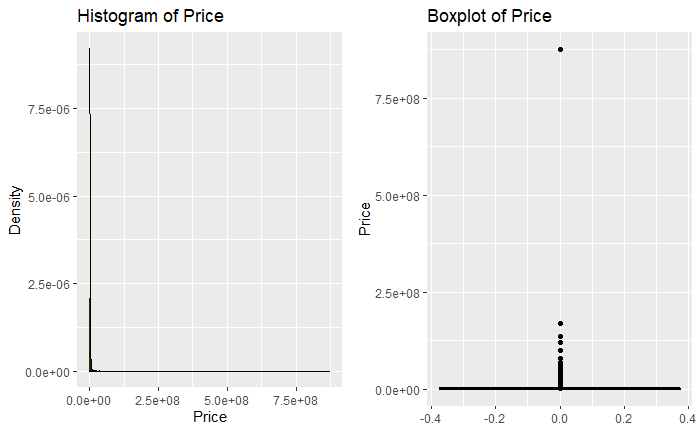

```r
library(ggplot2)

# Create a histogram of the price variable
histogram <- ggplot(realtor, aes(x = price)) +
  geom_histogram(binwidth = 10000, fill = "skyblue", color = "black", aes(y = ..density..), alpha = 0.7) +
  geom_density(alpha = 0.2, fill = "orange") +
  labs(title = "Histogram of Price", x = "Price", y = "Density")

# Create a boxplot of the price variable
boxplot <- ggplot(realtor, aes(y = price)) +
  geom_boxplot(fill = "lightgreen", color = "black") +
  labs(title = "Boxplot of Price", y = "Price")

# Display the histogram and boxplot side by side
library(gridExtra)
grid.arrange(histogram, boxplot, ncol = 2)

install.packages("gridExtra")
```

```r
cat('Variable has a summary that shows positive skewness. The mean value is higher than the median value, indicating that there are more lower values and fewer high values. The histogram of the variable will likely show a long tail on the right side, with most of the data concentrated at the lower end')
```

```
Variable has a summary that shows positive skewness. The mean value is higher than the median value, indicating that there are more lower values and fewer high values. The histogram of the variable will likely show a long tail on the right side, with most of the data concentrated at the lower end
```

8. what percentage of the observations are missing for the price variable?

```r
total_observations <- nrow(realtor)

# Calculate the number of missing observations for the price variable
missing_price <- sum(is.na(realtor$price))

# Calculate the percentage of missing observations
percentage_missing <- (missing_price / total_observations) * 100

# Print the percentage of missing observations for the price variable
print(percentage_missing)
```

```
[1] 0.007690983
```

9. Use as.Date method to convert the sold_date variable from character string to date/time type. Then from this date/time object create two new attributes (sold_year) and (sold_month) to store the year and month that the house was sold

```r
realtor$sold_date <- as.Date(realtor$sold_date, format = "%Y-%m-%d")

# Create sold_year and sold_month attributes
realtor$sold_year <- format(realtor$sold_date, "%Y")
realtor$sold_month <- format(realtor$sold_date, "%m")
str(realtor)
```

```
'data.frame':   923159 obs. of  14 variables:
 $ status      : chr  "for_sale" "for_sale" "for_sale" "for_sale" ...
 $ price       : num  105000 80000 67000 145000 65000 179000 50000 71600 100000 300000 ...
 $ bed         : num  3 4 2 4 6 4 3 3 2 5 ...
 $ bath        : num  2 2 1 2 2 3 1 2 1 3 ...
 $ acre_lot    : num  0.12 0.08 0.15 0.1 0.05 0.46 0.2 0.08 0.09 7.46 ...
 $ full_address: chr  "Sector Yahuecas Titulo # V84, Adjuntas, PR, 00601" "Km 78 9 Carr # 135, Adjuntas, PR, 00601" "556G 556-G 16 St, Juana Diaz, PR, 00795" "R5 Comunidad El Paraso Calle De Oro R-5 Ponce, Ponce, PR, 00731" ...
 $ street      : chr  "Sector Yahuecas Titulo # V84" "Km 78 9 Carr # 135" "556G 556-G 16 St" "R5 Comunidad El Paraso Calle De Oro R-5 Ponce" ...
 $ city        : chr  "Adjuntas" "Adjuntas" "Juana Diaz" "Ponce" ...
 $ state       : chr  "Puerto Rico" "Puerto Rico" "Puerto Rico" "Puerto Rico" ...
 $ zip_code    : num  601 601 795 731 680 612 639 731 730 670 ...
 $ house_size  : num  920 1527 748 1800 NA ...
 $ sold_date   : Date, format: NA NA NA NA ...
 $ sold_year   : chr  NA NA NA NA ...
 $ sold_month  : chr  NA NA NA NA ...
```

10. convert the “state” attribute to factor then take a summary to see how many observations are there for each state. Remove states with only one observation from the data

```r
realtor$state <- factor(realtor$state)

# Summary of observations for each state
state_summary <- table(realtor$state)

# Print the summary
print(state_summary)
```

```
   Connecticut       Delaware        Georgia          Maine  Massachusetts  New Hampshire     New Jersey
         91644           2135             50          36650         175248          51394         233722
      New York   Pennsylvania    Puerto Rico   Rhode Island South Carolina      Tennessee        Vermont
        211778          17148          24679          29596             25             20          46460
Virgin Islands       Virginia  West Virginia        Wyoming
          2573             31              3              3
```

```r
# Find states with only one observation
states_to_remove <- names(state_summary[state_summary == 1])

# Remove states with only one observation from the data
realtor <- realtor[!(realtor$state %in% states_to_remove), ]

# Summary after removal
state_summary_after_removal <- table(realtor$state)

# Print the summary after removal
print(state_summary_after_removal)
```

```
   Connecticut       Delaware        Georgia          Maine  Massachusetts  New Hampshire     New Jersey
         91644           2135             50          36650         175248          51394         233722
      New York   Pennsylvania    Puerto Rico   Rhode Island South Carolina      Tennessee        Vermont
        211778          17148          24679          29596             25             20          46460
Virgin Islands       Virginia  West Virginia        Wyoming
          2573             31              3              3
```

11. Is there a statistically significant difference between the average house price for different states? Use appropriate plot and statistic test to answer this question

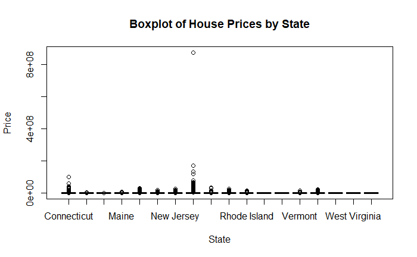

```r
boxplot(realtor$price ~ realtor$state, data = realtor, main = "Boxplot of House Prices by State", xlab = "State", ylab = "Price")
```

```r
library(ggplot2)
library(stats)


anova_result <- aov(realtor$price ~ realtor$state, data = realtor)
print(summary(anova_result))
```

```
                  Df    Sum Sq   Mean Sq F value Pr(>F)
realtor$state     17 2.177e+17 1.281e+16    1926 <2e-16 ***
Residuals     923070 6.137e+18 6.648e+12
---
Signif. codes:  0 ‘***’ 0.001 ‘**’ 0.01 ‘*’ 0.05 ‘.’ 0.1 ‘ ’ 1
71 observations deleted due to missingness
```

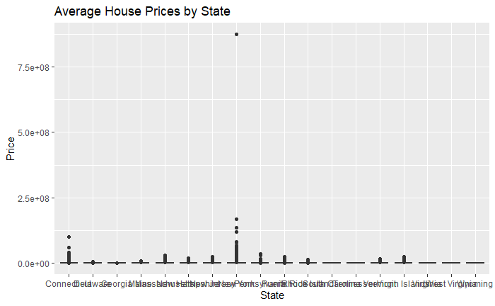

```r
ggplot(realtor, aes(x = realtor$state, y = realtor$price)) +
  geom_boxplot() +
  labs(title = "Average House Prices by State", x = "State", y = "Price")
```

```r
p.value <- summary(anova_result)$`Pr(>F)`[1]

if (isTRUE( p.value < 0.05)) {
  print("There is a statistically significant difference between the average house prices for the differentdifferent states.")
} else {
  print("There is not a statistically significant difference between the average house prices for the different states.")
}
```

[output not shown]

```r
realtor$price <- as.numeric(realtor$price)
realtor$sold_year <- as.numeric(realtor$sold_year)
realtor$house_size <- as.numeric(realtor$house_size)
realtor$bed <- as.numeric(realtor$bed)
realtor$bath <- as.numeric(realtor$bath)


correlation_sold_year <- cor(realtor$price, realtor$sold_year, method = "spearman", use = "pairwise.complete.obs")


correlation_house_size <- cor(realtor$price, realtor$house_size, method = "spearman", use = "pairwise.complete.obs")


correlation_bed <- cor(realtor$price, realtor$bed, method = "spearman", use = "pairwise.complete.obs")


correlation_bath <- cor(realtor$price, realtor$bath, method = "spearman", use = "pairwise.complete.obs")


cat("The Spearman rank correlation coefficient between house_price and sold_year is:", correlation_sold_year, "\n")
```

```
The Spearman rank correlation coefficient between house_price and sold_year is: -0.03400972
```

```r
cat("The Spearman rank correlation coefficient between house_price and house_size is:", correlation_house_size, "\n")
```

```
The Spearman rank correlation coefficient between house_price and house_size is: 0.4372374
```

```r
cat("The Spearman rank correlation coefficient between house_price and bed is:", correlation_bed, "\n")
```

```
The Spearman rank correlation coefficient between house_price and bed is: 0.2436678
```

```r
cat("The Spearman rank correlation coefficient between house_price and bath is:", correlation_bath,"\n")
```

```
The Spearman rank correlation coefficient between house_price and bath is: 0.4900013
```

```r
cat("Correlation coefficient between house_price and sold_year is approximately -0.034. This indicates a very weak negative monotonic relationship between house price and sold year. In other words, there is a slight tendency for house prices to decrease slightly as the year of sale increases. \n")
```

```
Correlation coefficient between house_price and sold_year is approximately -0.034. This indicates a very weak negative monotonic relationship between house price and sold year. In other words, there is a slight tendency for house prices to decrease slightly as the year of sale increases.
```

```r
cat("Correlation coefficient between house_price and house_size is approximately 0.437. This indicates a moderate positive monotonic relationship between house price and house size. In other words, as the size of the house increases, there is a tendency for the price of the house to increase. \n")
```

```
Correlation coefficient between house_price and house_size is approximately 0.437. This indicates a moderate positive monotonic relationship between house price and house size. In other words, as the size of the house increases, there is a tendency for the price of the house to increase.
```

```r
cat("Correlation coefficient between house_price and bed is approximately 0.244. This indicates a weak positive monotonic relationship between house price and the number of bedrooms. In other words, as the number of bedrooms increases, there is a tendency for the price of the house to increase \n")
```

```
Correlation coefficient between house_price and bed is approximately 0.244. This indicates a weak positive monotonic relationship between house price and the number of bedrooms. In other words, as the number of bedrooms increases, there is a tendency for the price of the house to increase
```

```r
cat("Correlation coefficient between house_price and bath is approximately 0.490. This indicates a moderate to strong positive monotonic relationship between house price and the number of bathrooms. In other words, as the number of bathrooms increases, there is a tendency for the price of the house to increase.  \n")
```

[output not shown]

Problem2 — Exploring Heart Disease Dataset 1.

```r
file1 <- read.csv("D:\\Machine Learning\\Assignment 1\\processed.cleveland.data", header = FALSE, na.strings = "?")


# Read the second file
file2 <- read.csv("D:\\Machine Learning\\Assignment 1\\processed.hungarian.data", header = FALSE, na.strings = "?")


# Read the third file
file3 <- read.csv("D:\\Machine Learning\\Assignment 1\\processed.switzerland.data", header = FALSE, na.strings = "?")


# Read the fourth file
file4 <- read.csv("D:\\Machine Learning\\Assignment 1\\processed.va.data", header = FALSE, na.strings = "?")
```

```r
HeartDisease <- rbind(file1, file2, file3, file4)
colnames(HeartDisease) <- c("age", "sex", "cp", "trestbps", "chol", "fbs", "restecg", "thalach", "exang", "oldpeak", "slope", "ca", "thal", "num")
```

```r
str(HeartDisease)
```

```
'data.frame':   920 obs. of  14 variables:
 $ age     : num  63 67 67 37 41 56 62 57 63 53 ...
 $ sex     : num  1 1 1 1 0 1 0 0 1 1 ...
 $ cp      : num  1 4 4 3 2 2 4 4 4 4 ...
 $ trestbps: num  145 160 120 130 130 120 140 120 130 140 ...
 $ chol    : num  233 286 229 250 204 236 268 354 254 203 ...
 $ fbs     : num  1 0 0 0 0 0 0 0 0 1 ...
 $ restecg : num  2 2 2 0 2 0 2 0 2 2 ...
 $ thalach : num  150 108 129 187 172 178 160 163 147 155 ...
 $ exang   : num  0 1 1 0 0 0 0 1 0 1 ...
 $ oldpeak : num  2.3 1.5 2.6 3.5 1.4 0.8 3.6 0.6 1.4 3.1 ...
 $ slope   : num  3 2 2 3 1 1 3 1 2 3 ...
 $ ca      : num  0 3 2 0 0 0 2 0 1 0 ...
 $ thal    : num  6 3 7 3 3 3 3 3 7 7 ...
 $ num     : int  0 2 1 0 0 0 3 0 2 1 ...
```

```r
# Summary statistics of the dataset
summary(HeartDisease)
```

```
      age             sex               cp          trestbps          chol            fbs
 Min.   :28.00   Min.   :0.0000   Min.   :1.00   Min.   :  0.0   Min.   :  0.0   Min.   :0.0000
 1st Qu.:47.00   1st Qu.:1.0000   1st Qu.:3.00   1st Qu.:120.0   1st Qu.:175.0   1st Qu.:0.0000
 Median :54.00   Median :1.0000   Median :4.00   Median :130.0   Median :223.0   Median :0.0000
 Mean   :53.51   Mean   :0.7891   Mean   :3.25   Mean   :132.1   Mean   :199.1   Mean   :0.1663
 3rd Qu.:60.00   3rd Qu.:1.0000   3rd Qu.:4.00   3rd Qu.:140.0   3rd Qu.:268.0   3rd Qu.:0.0000
 Max.   :77.00   Max.   :1.0000   Max.   :4.00   Max.   :200.0   Max.   :603.0   Max.   :1.0000
                                                 NA's   :59      NA's   :30      NA's   :90
    restecg          thalach          exang           oldpeak            slope             ca
 Min.   :0.0000   Min.   : 60.0   Min.   :0.0000   Min.   :-2.6000   Min.   :1.000   Min.   :0.0000
 1st Qu.:0.0000   1st Qu.:120.0   1st Qu.:0.0000   1st Qu.: 0.0000   1st Qu.:1.000   1st Qu.:0.0000
 Median :0.0000   Median :140.0   Median :0.0000   Median : 0.5000   Median :2.000   Median :0.0000
 Mean   :0.6046   Mean   :137.5   Mean   :0.3896   Mean   : 0.8788   Mean   :1.771   Mean   :0.6764
 3rd Qu.:1.0000   3rd Qu.:157.0   3rd Qu.:1.0000   3rd Qu.: 1.5000   3rd Qu.:2.000   3rd Qu.:1.0000
 Max.   :2.0000   Max.   :202.0   Max.   :1.0000   Max.   : 6.2000   Max.   :3.000   Max.   :3.0000
 NA's   :2        NA's   :55      NA's   :55       NA's   :62        NA's   :309     NA's   :611
      thal            num
 Min.   :3.000   Min.   :0.0000
 1st Qu.:3.000   1st Qu.:0.0000
 Median :6.000   Median :1.0000
 Mean   :5.088   Mean   :0.9957
 3rd Qu.:7.000   3rd Qu.:2.0000
 Max.   :7.000   Max.   :4.0000
 NA's   :486
```

```r
# Calculate the percentage of rows with missing values
missing_rows <- sum(!complete.cases(HeartDisease))
total_rows <- nrow(HeartDisease)
percentage_missing <- (missing_rows / total_rows) * 100
cat("The missing percentage is:", percentage_missing, "\n")
```

```
The missing percentage is: 67.5
```

```r
cat("age; numeric, continuous\n
    sex; Catagorical, nominal\n
    cp; Catagorical, ordinal\n
    trestbps; numeric, continuous\n
    chol; numeric, continuous\n
    fbs; Catagorical, nominal\n
    restecg; Catagorical, nominal\n
    thalach; numeric, continuous\n
    exang; Catagorical, nominal\n
    oldpeak; numeric, continuous\n
    slope; Catagorical, ordinal\n
    ca; numeric, discrete\n
    thal; Catagorical, ordinal\n
    num; numeric, discrete\n
    *ca* has an interval scale because the difference between values is meaningful (e.g., 1 major vessel vs. 2 major vessels).*thal* is more appropriately treated as an ordinal scale, where the values represent different levels or types of thalassemia.*num* has a nominal scale, where the values represent different categories without any inherent order.")
```

[output not shown]

4. Convert all categorical variables to “factor” using factor function ( set the “labels” option to give meaningful names/labels to each level)

```r
HeartDisease$sex <- factor(HeartDisease$sex, levels = c(0, 1), labels = c("Female", "Male"))

# Convert cp variable to factor with custom labels
HeartDisease$cp <- factor(HeartDisease$cp, levels = c(1, 2, 3, 4), labels = c("Typical Angina", "Atypical Angina", "Non-anginal Pain", "Asymptomatic"))

# Convert fbs variable to factor with custom labels
HeartDisease$fbs <- factor(HeartDisease$fbs, levels = c(0, 1), labels = c("<= 120 mg/dl", "> 120 mg/dl"))

# Convert restecg variable to factor with custom labels
HeartDisease$restecg <- factor(HeartDisease$restecg, levels = c(0, 1, 2), labels = c("Normal", "ST-T Wave Abnormality", "Left Ventricular Hypertrophy"))

# Convert exang variable to factor with custom labels
HeartDisease$exang <- factor(HeartDisease$exang, levels = c(0, 1), labels = c("No", "Yes"))

# Convert slope variable to factor with custom labels
HeartDisease$slope <- factor(HeartDisease$slope, levels = c(1, 2, 3), labels = c("Upsloping", "Flat", "Downsloping"))

# Convert thal variable to factor with custom labels
HeartDisease$thal <- factor(HeartDisease$thal, levels = c(3, 6, 7), labels = c("Normal", "Fixed Defect", "Reversible Defect"))

# Print the structure of the data frame to verify the changes
str(HeartDisease)
```

```
'data.frame':   920 obs. of  14 variables:
 $ age     : num  63 67 67 37 41 56 62 57 63 53 ...
 $ sex     : Factor w/ 2 levels "Female","Male": 2 2 2 2 1 2 1 1 2 2 ...
 $ cp      : Factor w/ 4 levels "Typical Angina",..: 1 4 4 3 2 2 4 4 4 4 ...
 $ trestbps: num  145 160 120 130 130 120 140 120 130 140 ...
 $ chol    : num  233 286 229 250 204 236 268 354 254 203 ...
 $ fbs     : Factor w/ 2 levels "<= 120 mg/dl",..: 2 1 1 1 1 1 1 1 1 2 ...
 $ restecg : Factor w/ 3 levels "Normal","ST-T Wave Abnormality",..: 3 3 3 1 3 1 3 1 3 3 ...
 $ thalach : num  150 108 129 187 172 178 160 163 147 155 ...
 $ exang   : Factor w/ 2 levels "No","Yes": 1 2 2 1 1 1 1 2 1 2 ...
 $ oldpeak : num  2.3 1.5 2.6 3.5 1.4 0.8 3.6 0.6 1.4 3.1 ...
 $ slope   : Factor w/ 3 levels "Upsloping","Flat",..: 3 2 2 3 1 1 3 1 2 3 ...
 $ ca      : num  0 3 2 0 0 0 2 0 1 0 ...
 $ thal    : Factor w/ 3 levels "Normal","Fixed Defect",..: 2 1 3 1 1 1 1 1 3 3 ...
 $ num     : int  0 2 1 0 0 0 3 0 2 1 ...
```

```r
Mode <- function(x) {
  ux <- unique(x)
  ux[which.max(tabulate(match(x, ux)))]
}

# Calculate median
median_age <- median(HeartDisease$age, na.rm = TRUE)

# Calculate mode
mode_age <- Mode(HeartDisease$age)

# Print the results
print(paste("Median age:", median_age))
```

```
[1] "Median age: 54"
```

```r
print(paste("Mode age:", mode_age))
```

```
[1] "Mode age: 54"
```

```r
HeartDisease$diagnosis <- factor(ifelse(HeartDisease$num == 0, "No", "Yes"), levels = c("No", "Yes"))

# Remove column 14 (num) from the dataframe
HeartDisease <- HeartDisease[, -14]

# Print the structure of the modified dataframe
str(HeartDisease)
```

```
'data.frame':   920 obs. of  14 variables:
 $ age      : num  63 67 67 37 41 56 62 57 63 53 ...
 $ sex      : Factor w/ 2 levels "Female","Male": 2 2 2 2 1 2 1 1 2 2 ...
 $ cp       : Factor w/ 4 levels "Typical Angina",..: 1 4 4 3 2 2 4 4 4 4 ...
 $ trestbps : num  145 160 120 130 130 120 140 120 130 140 ...
 $ chol     : num  233 286 229 250 204 236 268 354 254 203 ...
 $ fbs      : Factor w/ 2 levels "<= 120 mg/dl",..: 2 1 1 1 1 1 1 1 1 2 ...
 $ restecg  : Factor w/ 3 levels "Normal","ST-T Wave Abnormality",..: 3 3 3 1 3 1 3 1 3 3 ...
 $ thalach  : num  150 108 129 187 172 178 160 163 147 155 ...
 $ exang    : Factor w/ 2 levels "No","Yes": 1 2 2 1 1 1 1 2 1 2 ...
 $ oldpeak  : num  2.3 1.5 2.6 3.5 1.4 0.8 3.6 0.6 1.4 3.1 ...
 $ slope    : Factor w/ 3 levels "Upsloping","Flat",..: 3 2 2 3 1 1 3 1 2 3 ...
 $ ca       : num  0 3 2 0 0 0 2 0 1 0 ...
 $ thal     : Factor w/ 3 levels "Normal","Fixed Defect",..: 2 1 3 1 1 1 1 1 3 3 ...
 $ diagnosis: Factor w/ 2 levels "No","Yes": 1 2 2 1 1 1 2 1 2 2 ...
```

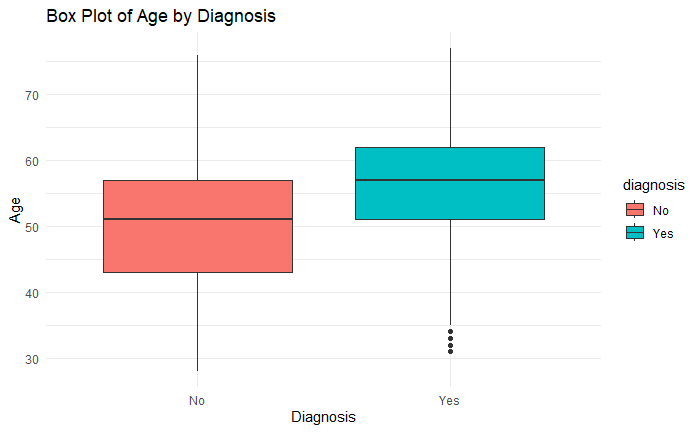

```r
ggplot(HeartDisease, aes(x = HeartDisease$diagnosis, y = HeartDisease$age, fill = diagnosis)) +
  geom_boxplot() +
  labs(title = "Box Plot of Age by Diagnosis",
       x = "Diagnosis", y = "Age") +
  theme_minimal()
```

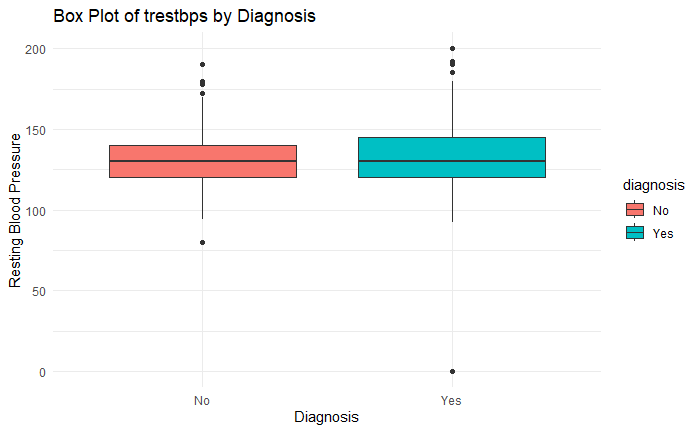

```r
ggplot(HeartDisease, aes(x = HeartDisease$diagnosis, y = HeartDisease$trestbps, fill = diagnosis)) +
  geom_boxplot() +
  labs(title = "Box Plot of trestbps by Diagnosis",
       x = "Diagnosis", y = "Resting Blood Pressure") +
  theme_minimal()
```

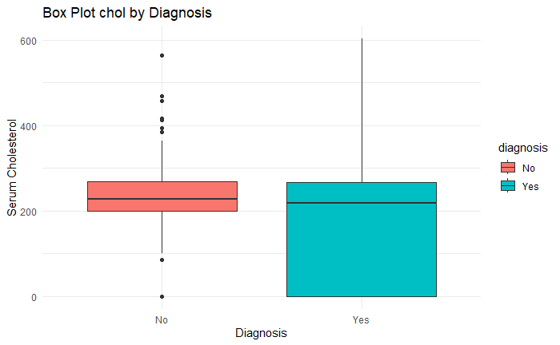

```r
ggplot(HeartDisease, aes(x = diagnosis, y = chol, fill = diagnosis)) +
  geom_boxplot() +
  labs(title = "Box Plot chol by Diagnosis",
       x = "Diagnosis", y = "Serum Cholesterol") +
  theme_minimal()
```

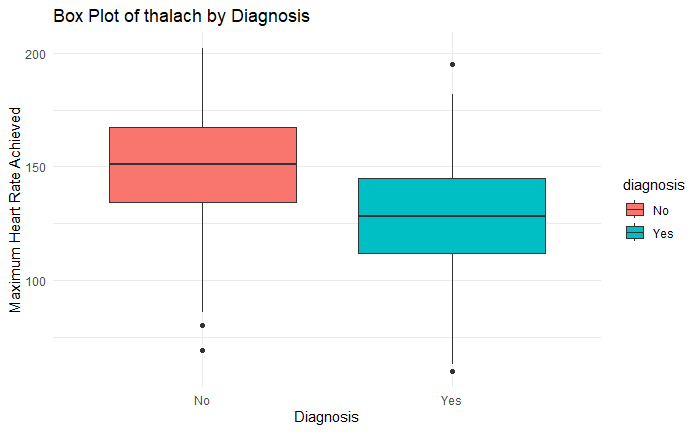

```r
ggplot(HeartDisease, aes(x = diagnosis, y = thalach, fill = diagnosis)) +
  geom_boxplot() +
  labs(title = "Box Plot of thalach by Diagnosis",
       x = "Diagnosis", y = "Maximum Heart Rate Achieved") +
  theme_minimal()
```

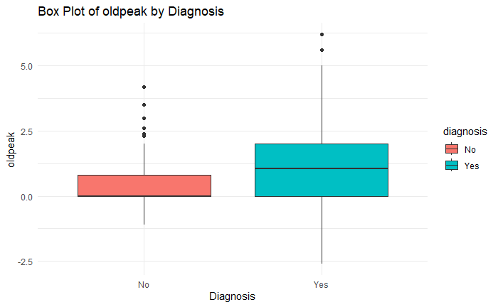

```r
ggplot(HeartDisease, aes(x = diagnosis, y = oldpeak, fill = diagnosis)) +
  geom_boxplot() +
  labs(title = "Box Plot of oldpeak by Diagnosis",
       x = "Diagnosis", y = "oldpeak") +
  theme_minimal()
```

```
[1] "T-test p-value for age and diagnosis : 0.000000000000000004842782"
```

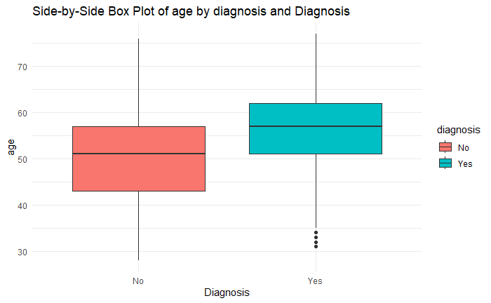

```r
library(ggplot2)
library(dplyr)

# Function to perform t-test and plot side-by-side boxplot for numeric variables with two groups
test_and_plot_numeric_t_test <- function(data, numeric_variable, categorical_variable) {
  t_test <- t.test(data[[numeric_variable]] ~ data[[categorical_variable]])
  print(paste("T-test p-value for", numeric_variable, "and", categorical_variable, ":", format(t_test$p.value, scientific = FALSE)))
  ggplot(data, aes(x = diagnosis, y = .data[[numeric_variable]], fill = .data[[categorical_variable]])) +
    geom_boxplot(position = position_dodge()) +
    labs(title = paste("Side-by-Side Box Plot of", numeric_variable, "by", categorical_variable, "and Diagnosis"),
         x = "Diagnosis", y = numeric_variable) +
    theme_minimal()
}

# Apply function to each numeric continuous variable
test_and_plot_numeric_t_test(HeartDisease, "age", "diagnosis")
```

```
[1] "T-test p-value for trestbps and diagnosis : 0.001485277"
```

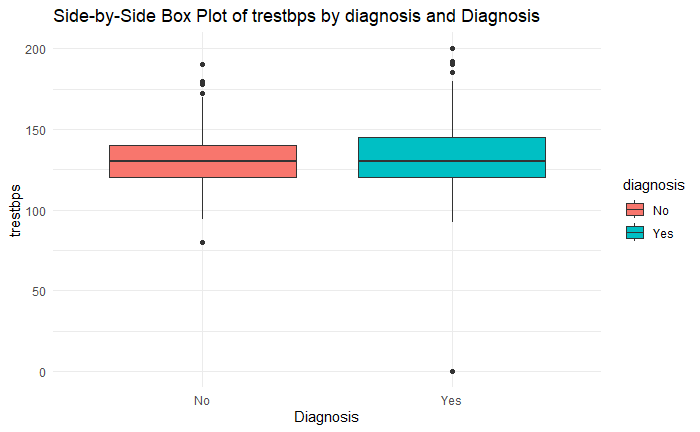

```r
test_and_plot_numeric_t_test(HeartDisease, "trestbps", "diagnosis")
```

```
[1] "T-test p-value for chol and diagnosis : 0.0000000000001951116"
```

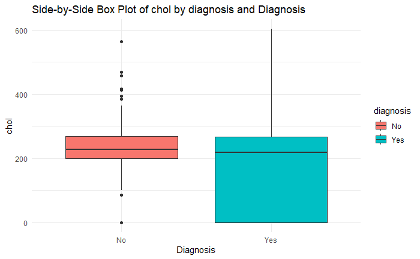

```r
test_and_plot_numeric_t_test(HeartDisease, "chol", "diagnosis")
```

```
[1] "T-test p-value for thalach and diagnosis : 0.000000000000000000000000000000001301582"
```

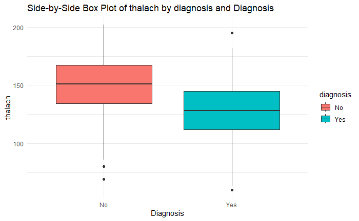

```r
test_and_plot_numeric_t_test(HeartDisease, "thalach", "diagnosis")
```

```
[1] "T-test p-value for oldpeak and diagnosis : 0.0000000000000000000000000000000005077156"
```

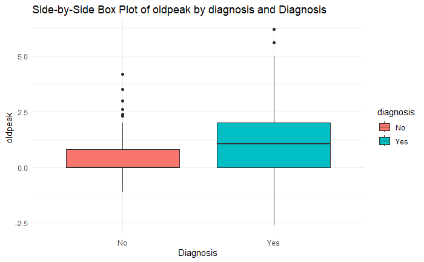

```r
test_and_plot_numeric_t_test(HeartDisease, "oldpeak", "diagnosis")
```

```
[1] "Chi-squared test p-value for sex : 0.00000000000000000002485453"
```

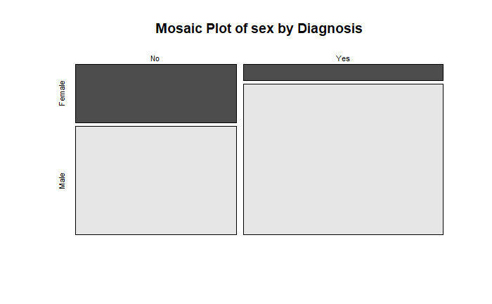

```r
library(ggplot2)
library(dplyr)

# Function to perform chi-squared test and plot mosaic plot for categorical variables
test_and_plot_categorical <- function(data, variable) {
  contingency_table <- table(data$diagnosis, data[[variable]])
  chi_squared_test <- chisq.test(contingency_table)
  print(paste("Chi-squared test p-value for", variable, ":", format(chi_squared_test$p.value, scientific = FALSE)))
  mosaicplot(contingency_table, main = paste("Mosaic Plot of", variable, "by Diagnosis"), color = TRUE)
}

# Apply function to each categorical nominal variable
test_and_plot_categorical(HeartDisease, "sex")
```

```
[1] "Chi-squared test p-value for fbs : 0.00005971604"
```

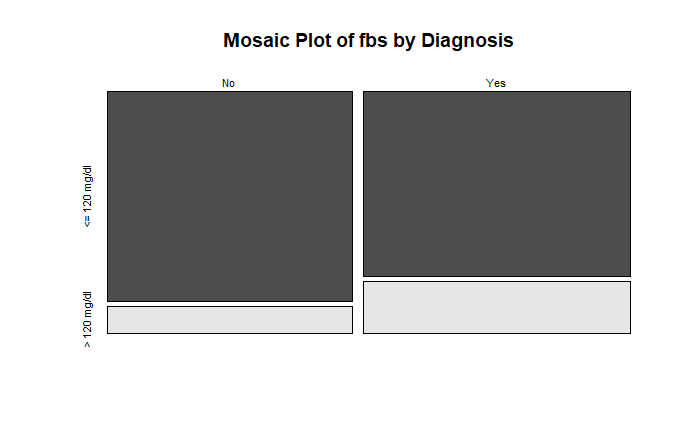

```r
test_and_plot_categorical(HeartDisease, "fbs")
```

```
[1] "Chi-squared test p-value for restecg : 0.002862841"
```

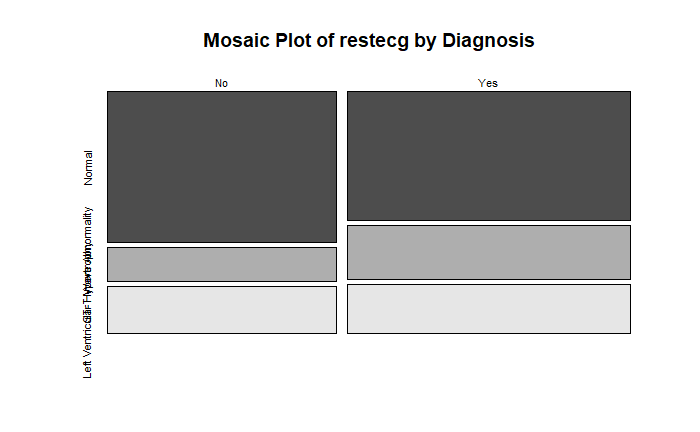

```r
test_and_plot_categorical(HeartDisease, "restecg")
```

```
[1] "Chi-squared test p-value for exang : 0.000000000000000000000000000000000000000006422657"
```

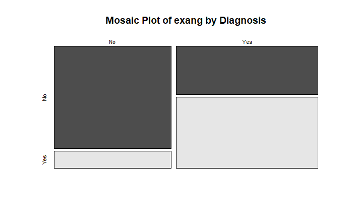

```r
test_and_plot_categorical(HeartDisease, "exang")
```

```r
library(ggplot2)
library(vcd)

# Perform chi-squared test for independence
chi_squared_test <- chisq.test(HeartDisease$diagnosis, HeartDisease$cp)

# Print the p-value of the chi-squared test
print(paste("Chi-squared test p-value:", format(chi_squared_test$p.value, scientific = FALSE)))
```

```
[1] "Chi-squared test p-value: 0.0000000000000000000000000000000000000000000000000000000007036525"
```

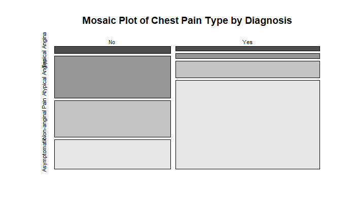

```r
# Create a mosaic plot
mosaicplot(table(HeartDisease$diagnosis, HeartDisease$cp),
           main = "Mosaic Plot of Chest Pain Type by Diagnosis",
           color = TRUE)
```

```r
# Perform chi-squared test for independence
chi_squared_test_slope <- chisq.test(HeartDisease$diagnosis, HeartDisease$slope)

# Print the p-value of the chi-squared test
print(paste("Chi-squared test p-value for slope:", format(chi_squared_test_slope$p.value, scientific = FALSE)))
```

```
[1] "Chi-squared test p-value for slope: 0.00000000000000000005082621"
```

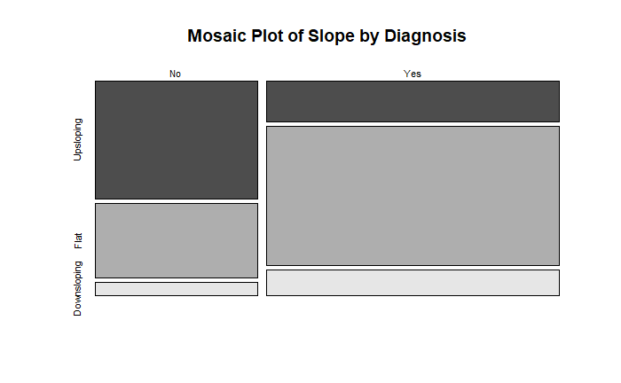

```r
# Create a mosaic plot
mosaicplot(table(HeartDisease$diagnosis, HeartDisease$slope),
           main = "Mosaic Plot of Slope by Diagnosis",
           color = TRUE)
```

```r
chi_squared_test_thal <- chisq.test(HeartDisease$diagnosis, HeartDisease$thal)

# Print the p-value of the chi-squared test
print(paste("Chi-squared test p-value for thal:", format(chi_squared_test_thal$p.value, scientific = FALSE)))
```

```
[1] "Chi-squared test p-value for thal: 0.000000000000000000000002092466"
```

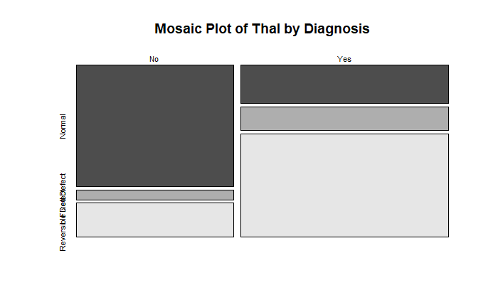

```r
# Create a mosaic plot
mosaicplot(table(HeartDisease$diagnosis, HeartDisease$thal),
           main = "Mosaic Plot of Thal by Diagnosis",
           color = TRUE)
```

```r
NA
NA
```

```r
library(ggplot2)

# Perform ANOVA
anova_result <- aov(ca ~ diagnosis, data = HeartDisease)

# Print the summary of the ANOVA
print(summary(anova_result))
```

```
             Df Sum Sq Mean Sq F value Pr(>F)
diagnosis     1  55.97   55.97   80.42 <2e-16 ***
Residuals   307 213.67    0.70
---
Signif. codes:  0 ‘***’ 0.001 ‘**’ 0.01 ‘*’ 0.05 ‘.’ 0.1 ‘ ’ 1
611 observations deleted due to missingness
```

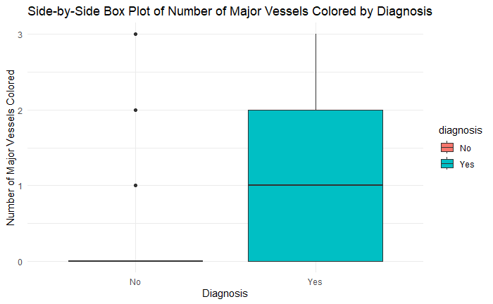

```r
# Create a side-by-side boxplot
ggplot(HeartDisease, aes(x = diagnosis, y = ca, fill = diagnosis)) +
  geom_boxplot() +
  labs(title = "Side-by-Side Box Plot of Number of Major Vessels Colored by Diagnosis",
       x = "Diagnosis",
       y = "Number of Major Vessels Colored") +
  theme_minimal()
```

```r
NA
NA
```